# The Model-Fitting Paradigm in R

```r
library(tidyverse)
library(tidymodels)
library(gapminder)
```

From today’s class, students are anticipated to be able to:

- make a model object in R, using `lm()` as an example.
- write a formula in R.
- predict on a model object with the `broom::augment()` and `predict()` functions.
- extract information from a model object using `broom::tidy()`, `broom::glance()`, and traditional means.

Note that there is a new tidyverse-like framework of packages to help with modelling. It’s called [tidymodels](https://www.tidymodels.org/).

## Resources

Video lecture:

- [The Model-Fitting Paradigm in R](https://youtu.be/jQqCDeJYzao)

Other resources, in addition to the notes below:

- The [broom vignette](https://cran.r-project.org/web/packages/broom/vignettes/broom.html) is useful for learning the details of broom, a package for tidying the output of models.
- If you want a quick intro to linear regression with R, check out this [U Chicago Tutorial](https://cfss.uchicago.edu/notes/linear-models/) on model fitting in R (just the linear regression part).
- If you’re eager to learn more about models in general, [An Introduction to Statistical Learning](https://www-bcf.usc.edu/~gareth/ISL/) is an approachable read (the book is freely available online)
- [Mike Marin’s R playlist on YouTube](https://www.youtube.com/playlist?list=PLqzoL9-eJTNBlVXxWvJkq0dtVut2sICUW) helps you use R to obtain statistical results.

# Model-fitting in R

Data wrangling and plotting can get you pretty far when it comes to drawing insight from your data. But, sometimes you need to go further. For example:

- Investigate the relationship between two or more variables
- Predict the outcome of a variable given information about other variables

These typically involve fitting models, as opposed to simple computations than can be done with tidyverse packages like dplyr.

This tutorial is *not* about the specifics of fitting a model. Even though a few references to statistical concepts are made, just take these for face value.

## Example: linear model

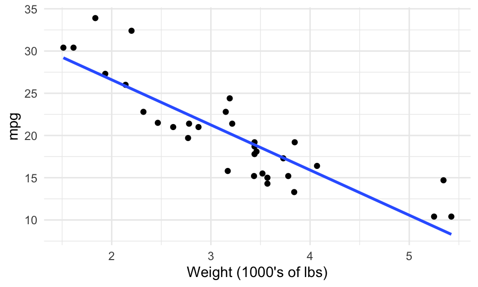

(By the way, you can plot the model using `ggplot2`’s `geom_smooth()` layer – but you can’t interact with the model downstream.)

We can make a prediction of mpg for a car weighing 3,000 lbs by evaluating the line at X = 3:

```
## [1] 21.25171
```

We can find the p-value testing the null hypothesis that the true slope of the regression line is 0:

```
## [1] 1.293959e-10
```

And we can calculate how many more miles per gallon a car weighing 1000 less lbs would be expected to have through the slope:

```
## [1] 5.344472
```

## Fitting a model in R

Fitting a model in R typically involves using a function in the following format:

```
method(formula, data, options)
```

**Method**:

A function such as:

- Linear Regression: `lm`
- Generalized Linear Regression: `glm`
- Local regression: `loess`
- Quantile regression: `quantreg::rq`
- …

**Formula**:

In R, takes the form `y ~ x1 + x2 + ... + xp` (use column names in your data frame), where `y` here means the outcome variable you’re interested in viewing in relation to other variables `x1`, `x2`, …

**Data**: The data frame or tibble. Can omit, if variables in the formula are defined in environment

**Options**: Specific to the method, and include ways to customize the model.

Running the code returns an object – usually a special type of list – that you can then work with to extract results.

For example, let’s fit a linear regression model on a car’s mileage per gallon (`mpg`, “Y” variable) from the car’s weight (`wt`, “X” variable). Notice that no special options are needed for `lm()`.

```r
(my_lm <- lm(mpg ~ wt, data = mtcars))
```

```
##
## Call:
## lm(formula = mpg ~ wt, data = mtcars)
##
## Coefficients:
## (Intercept)           wt
##      37.285       -5.344
```

Printing the model to the screen might lead you to incorrectly conclude that the model object `my_lm` only contains the above text. The reality is, `my_lm` contains a lot more, but special instructions have been given to R to only print out a special digested version of the object. This behaviour tends to be true with model objects in general, not just for `lm()`.

## Probing the model: Broom

Now that you have the model object, there are typically three ways in which it’s useful to probe and use the model object. The `broom` package has three crown functions that make it easy to extract each piece of information by converting your model into a tibble:

1. `tidy`: extract statistical summaries about each “component” of the model.
2. `augment`: add columns to the original data frame containing predictions.
3. `glance`: extract statistical summaries about the model as a whole (a 1-row tibble).

### `tidy()`

Use the `tidy()` function for a statistical summary of each component of your model, where each component gets a row in the output tibble. For `lm()`, `tidy()` gives one row per regression coefficient (slope and intercept).

```r
tidy(my_lm)
```

```
## # A tibble: 2 × 5
##   term        estimate std.error statistic  p.value
##   <chr>          <dbl>     <dbl>     <dbl>    <dbl>
## 1 (Intercept)    37.3      1.88      19.9  8.24e-19
## 2 wt             -5.34     0.559     -9.56 1.29e-10
```

`tidy()` only works if it makes sense to talk about model “components”.

### `augment()`

Use the `augment()` function to make predictions on a dataset by augmenting predictions as a new column to your data. By default, `augment()` uses the dataset that was used to fit the model.

```r
augment(my_lm) %>%
  print(n = 5)
```

```
## # A tibble: 32 × 9
##   .rownames           mpg    wt .fitted .resid   .hat .sigma  .cooksd .std.resid
##   <chr>             <dbl> <dbl>   <dbl>  <dbl>  <dbl>  <dbl>    <dbl>      <dbl>
## 1 Mazda RX4          21    2.62    23.3 -2.28  0.0433   3.07  1.33e-2    -0.766
## 2 Mazda RX4 Wag      21    2.88    21.9 -0.920 0.0352   3.09  1.72e-3    -0.307
## 3 Datsun 710         22.8  2.32    24.9 -2.09  0.0584   3.07  1.54e-2    -0.706
## 4 Hornet 4 Drive     21.4  3.22    20.1  1.30  0.0313   3.09  3.02e-3     0.433
## 5 Hornet Sportabout  18.7  3.44    18.9 -0.200 0.0329   3.10  7.60e-5    -0.0668
## # ℹ 27 more rows
```

We can also predict on new datasets. Here are predictions of `mpg` for cars weighing 3, 4, and 5 thousand lbs.

```r
augment(my_lm, newdata = tibble(wt = 3:5))
```

```
## # A tibble: 3 × 2
##      wt .fitted
##   <int>   <dbl>
## 1     3    21.3
## 2     4    15.9
## 3     5    10.6
```

Notice that only the “X” variables are needed in the input tibble (`wt`), and that since the “Y” variable (`mpg`) wasn’t provided, `augment()` couldn’t calculate anything besides a prediction.

### `glance()`

Use the `glance()` function to extract a summary of the model as a whole, in the form of a one-row tibble. This will give you information related to the model fit.

```r
glance(my_lm)
```

```
## # A tibble: 1 × 12
##   r.squared adj.r.squared sigma statistic  p.value    df logLik   AIC   BIC
##       <dbl>         <dbl> <dbl>     <dbl>    <dbl> <dbl>  <dbl> <dbl> <dbl>
## 1     0.753         0.745  3.05      91.4 1.29e-10     1  -80.0  166.  170.
## # ℹ 3 more variables: deviance <dbl>, df.residual <int>, nobs <int>
```

## Probing the Model: Traditional Method

In order for a model to work with the `broom` package, someone has to go out of their way to contribute to the `broom` package for that model. While this has happened for many common models, many others remain without `broom` compatibility.

Here’s how to work with these model objects in that case.

### Prediction

If `broom::augment()` doesn’t work, then the developer of the model almost surely made it so that the `predict()` function works (not part of the `broom` package). The `predict()` function typically takes the same format of the `augment()` function, but usually doesn’t return a tibble.

Here are the first 5 predictions of mpg on the `my_lm` object, defaulting to predictions made on the original data:

```r
predict(my_lm) %>%
  unname() %>%
  head(5)
```

```
## [1] 23.28261 21.91977 24.88595 20.10265 18.90014
```

Here are the predictions of mpg made for cars with a weight of 3, 4, and 5 thousand lbs:

```r
predict(my_lm, newdata = tibble(wt = 3:5)) %>%
  unname()
```

```
## [1] 21.25171 15.90724 10.56277
```

Checking the documentation of the `predict()` function *for your model* isn’t obvious, because the `predict()` function is a “generic” function. Your best bet is to append the model name after a dot. For example:

- For a model fit with `lm()`, try `?predict.lm`
- For a model fit with `rq()`, try `?predict.rq` (from the `quantreg` package)

If that doesn’t work, just google it: `"Predict function for rq"`

### Functions designed for the model

The developer of the model probably made a suite of other functions to help you probe the model object. Check the documentation to find these.

For example, I can find the regression coefficients of a `lm()` object with `coef()`:

```r
coef(my_lm)
```

```
## (Intercept)          wt
##   37.285126   -5.344472
```

Standard error of the residuals with `sigma()`:

```r
sigma(my_lm)
```

```
## [1] 3.045882
```

Don’t be surprised if there is no function to extract what you want. If that’s the case, read on…

### Manually Extracting Information

If you can’t extract model information from built-in functions like `coef()` or `sigma()`, you can manually dig in to the model object. In most cases, a model object is just a list in disguise! You can therefore extract information like you would with any other list.

To help figure out what’s in the list, use the `names()` function. Here are all the entries in the `lm()` object we fit earlier:

```r
names(my_lm)
```

```
##  [1] "coefficients"  "residuals"     "effects"       "rank"
##  [5] "fitted.values" "assign"        "qr"            "df.residual"
##  [9] "xlevels"       "call"          "terms"         "model"
```

Want the degrees of freedom of the residuals? Just extract that entry:

```r
my_lm$df.residual
```

```
## [1] 30
```

To complicate things further this might only be *part* of the information made available in the model object! More info might be stored in *yet another* list after applying the `summary()` function:

```r
summary(my_lm)
```

```
##
## Call:
## lm(formula = mpg ~ wt, data = mtcars)
##
## Residuals:
##     Min      1Q  Median      3Q     Max
## -4.5432 -2.3647 -0.1252  1.4096  6.8727
##
## Coefficients:
##             Estimate Std. Error t value Pr(>|t|)
## (Intercept)  37.2851     1.8776  19.858  < 2e-16 ***
## wt           -5.3445     0.5591  -9.559 1.29e-10 ***
## ---
## Signif. codes:  0 '***' 0.001 '**' 0.01 '*' 0.05 '.' 0.1 ' ' 1
##
## Residual standard error: 3.046 on 30 degrees of freedom
## Multiple R-squared:  0.7528, Adjusted R-squared:  0.7446
## F-statistic: 91.38 on 1 and 30 DF,  p-value: 1.294e-10
```

Like the original model object, `summary()` *looks* like it returns a bunch of text – but it’s actually another list! Let’s again use `names()` to get the components of this list:

```r
names(summary(my_lm))
```

```
##  [1] "call"          "terms"         "residuals"     "coefficients"
##  [5] "aliased"       "sigma"         "df"            "r.squared"
##  [9] "adj.r.squared" "fstatistic"    "cov.unscaled"
```

Now I can get more pieces of information, like the adjusted R-squared value:

```r
summary(my_lm)$adj.r.squared
```

```
## [1] 0.7445939
```

## Plotting models with `geom_smooth`

We can plot models (with one predictor/ X variable) using `ggplot2` through the `geom_smooth()` layer. Specifying `method="lm"` gives us the linear regression fit (but only visually – very difficult to extract model components!):

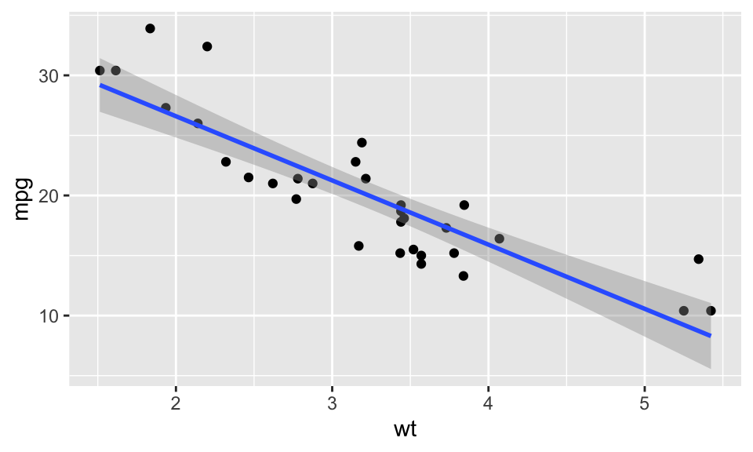

```r
ggplot(mtcars, aes(x = wt, y = mpg)) +
    geom_point() +
    geom_smooth(method = "lm")
```

Let’s visualize some relationships in the `gapminder` dataset.

Let’s inspect Zimbabwe, which has a unique behavior in the `lifeExp` and `year` relationship.

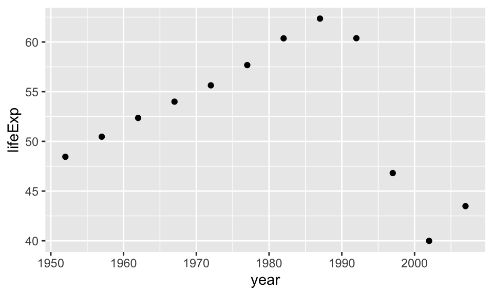

```r
gapminder_Zimbabwe <- gapminder %>%
  filter(country == "Zimbabwe")

gapminder_Zimbabwe %>%
  ggplot(aes(year, lifeExp)) +
  geom_point()
```

Let’s try fitting a linear model to this relationship

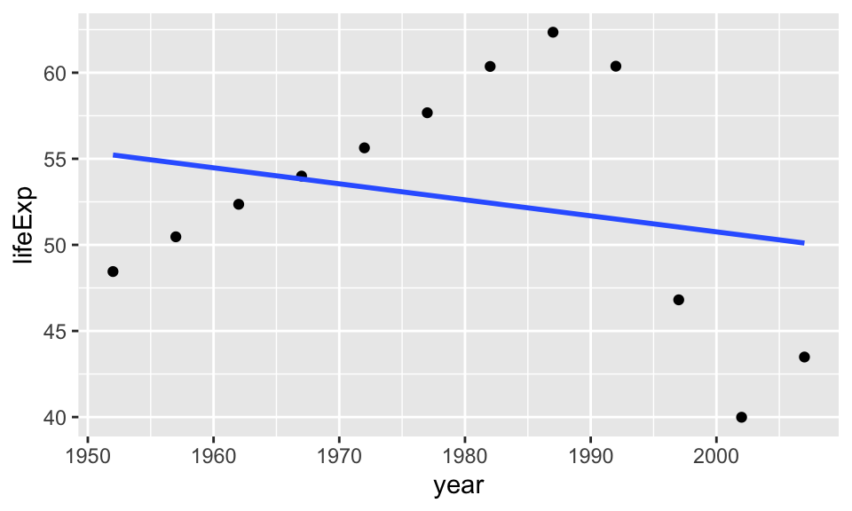

```r
ggplot(gapminder_Zimbabwe, aes(year,lifeExp)) +
  geom_point() +
  geom_smooth(method = "lm", se = F)
```

Now we will try to fit a second degree polynomial and see what would that look like.

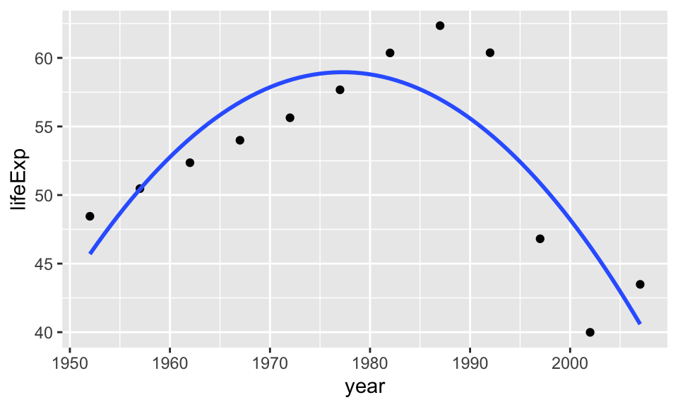

```r
ggplot(gapminder_Zimbabwe, aes(year,lifeExp)) +
  geom_point() +
  geom_smooth(method = "lm",
              formula = y ~ poly(x,2),
              se = F)
```

## Summary

1. `function(formula, data, options)` - most models in R follow this structure.
2. `broom::augment()` - uses a fitted model to obtain predictions. Puts this in a new column in existing `tibble`. Equivalent base-r function is `predict()`.
3. `broom::tidy()` - used to extract statistical information on each component of a model. Equivalent is `coef(summary(lm_object))`.
4. `broom::glance()` - used to extract statistical summaries on the whole model. Always returns a 1-row `tibble`.
5. `geom_smooth()` - used to add geom_layer that shows a fitted line to the data. `method` and `formula` arguments can be used to customize model.

## Test Your Understanding

1. TRUE or FALSE: the output of `glance` on the above returns only 1 row because there is only 1 explanatory variable in the model.
2. TRUE or FALSE: the output of `broom::tidy()` package is more “tidy” than `coef(summary())` because the output is a `tibble`
3. TRUE or FALSE: We need to use a modelling function, such as `lm`, before we can graph a fitted line with `geom_smooth`.
4. TRUE or FALSE: If I wanted to find the amount that `lifeExp` changes per `year`, then I need to use `broom::tidy()`

## Your turn: learning to fit models in R

We think the best way to learn the basics from here is to work through the last part of Worksheet A4.